# Lecture 2. Linear models

### Radial Basis Function (RBF) kernel

- The **RBF or Gaussian kernel** (of width $\gamma > 0$) is related to the Taylor series expansion of $e^x$

$$\Phi(x) = e^{-x^2/2\gamma^2} \Big[ 1, \sqrt{\frac{1}{1!\gamma^2}}x,\sqrt{\frac{1}{2!\gamma^4}}x^2,\sqrt{\frac{1}{3!\gamma^6}}x^3,\ldots\Big]^T$$

- It is a function of how closely together two data points are:

$$k_{RBF}(\mathbf{x_1},\mathbf{x_2}) = exp(-\gamma ||\mathbf{x_1} - \mathbf{x_2}||^2)$$

- The influence of a point $\mathbf{x_2}$ on point $\mathbf{x_1}$ drops off exponentially with its distance to $\mathbf{x_1}$
- The influence of each support vector now drops of *exponentially*
  - Hence, predictions are only affected by very nearby support vectors
- RBF kernels are therefore called *local* kernels

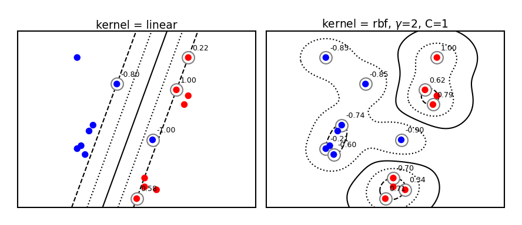

- The kernel width ($\gamma$) defines how sharply the local influence decays
  - Acts as a regularizer: low $\gamma$ causes *underfitting* and high $\gamma$ causes *overfitting*
- SVM's C parameter (inverse regularizer) is still at play and thus interacts with $\gamma$

```
interactive(children=(FloatSlider(value=4.6, description='gamma', max=10.0, min=0.1, step=0.5), FloatSlider(va…
```

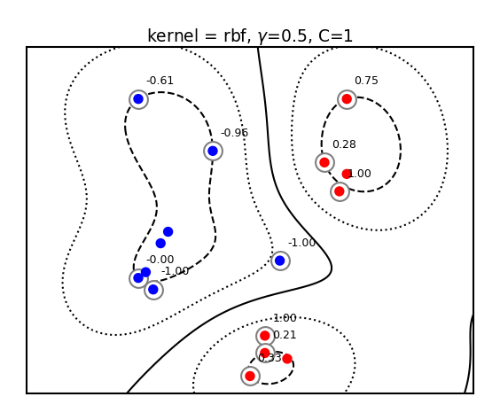

#### Kernelization sidenotes (optional)

- You can invent many more feature maps and corresponding kernels (eg. for text, graphs,...)
  - However, learning deep learning embeddings from lots of data often works better
- You can also kernelize Ridge regression, Logistic regression, Perceptrons, Support Vector Regression,...
  - The *Representer theorem* will give you the corresponding loss function
- For more detail see the Kernelization lecture under extra materials.

#### SVMs in scikit-learn

- `svm.LinearSVC`: faster for large datasets
  - Allows choosing between the primal or dual. Primal recommended when $n$ >> $p$
  - Returns `coef_` ($\mathbf{w}$) and `intercept_` ($w_0$)
- `svm.SVC` allows different kernels to be used
  - Also returns `support_vectors_` (the support vectors) and the `dual_coef_` $a_i$
  - Scales at least quadratically with the number of samples $n$
- `svm.LinearSVR` and `svm.SVR` are variants for regression

```
clf = svm.SVC(kernel='linear') # or 'RBF' or 'Poly'
clf.fit(X, Y)
print("Support vectors:", clf.support_vectors_[:])
print("Coefficients:", clf.dual_coef_[:])
```

```
Support vectors:
[[-1.021  0.241]
 [-0.467 -0.531]
 [ 0.951  0.58 ]]
Coefficients:
[[-0.048 -0.569  0.617]]
```

### Solving SVMs with Gradient Descent

- SVMs can, alternatively, be solved using gradient decent
  - Good for large datasets, but does not yield support vectors or kernelization
- Hinge loss is not differentiable but convex, and has a subgradient:

$$\mathcal{L_{Hinge}}(\mathbf{w}) = max(0,1-y_i (\mathbf{w}\mathbf{x_i} + w_0))$$

$$\frac{\partial \mathcal{L_{Hinge}}}{\partial w_i} = \begin{cases}-y_i x_i & y_i (\mathbf{w}\mathbf{x_i} + w_0) < 1\\ 0 & \text{otherwise} \\ \end{cases}$$

- Can be solved with (stochastic) gradient descent

### Generalized SVMs

- There are many smoothed versions of hinge loss:
  - Squared hinge loss:
    - Also known as *Ridge classification*
    - Least Squares SVM: allows kernelization (using a linear equation solver)
  - Modified Huber loss: squared hinge, but linear after -1. Robust against outliers
  - Log loss: equivalent to logistic regression
- In sklearn, `SGDClassifier` can be used with any of these. Good for large datasets.

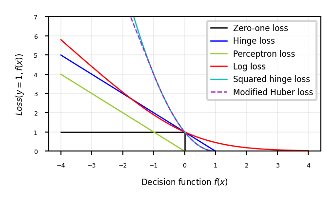

### Perceptron

- Represents a single neuron (node) with inputs $x_i$, a bias $w_0$, and output $y$
- Each connection has a (synaptic) weight $w_i$. The node outputs $\hat{y} = \sum_{i}^n x_{i}w_i + w_0$
- The *activation function* (neuron output) is 1 if $\mathbf{xw} + w_0 > 0$, -1 otherwise
- Idea: Update synapses *only* on misclassification, correct output by exactly $\pm1$
- Weights can be learned with (stochastic) gradient descent and Hinge(0) loss

  $$\mathcal{L}_{Perceptron} = max(0,-y_i (\mathbf{w}\mathbf{x_i} + w_0))$$

  $$\frac{\partial \mathcal{L_{Perceptron}}}{\partial w_i} = \begin{cases}-y_i x_i & y_i (\mathbf{w}\mathbf{x_i} + w_0) < 0\\ 0 & \text{otherwise} \\ \end{cases}$$

[figure not shown]

## Linear Models for multiclass classification

### one-vs-rest (aka one-vs-all)

- Learn a binary model for each class vs. all other classes
- Create as many binary models as there are classes

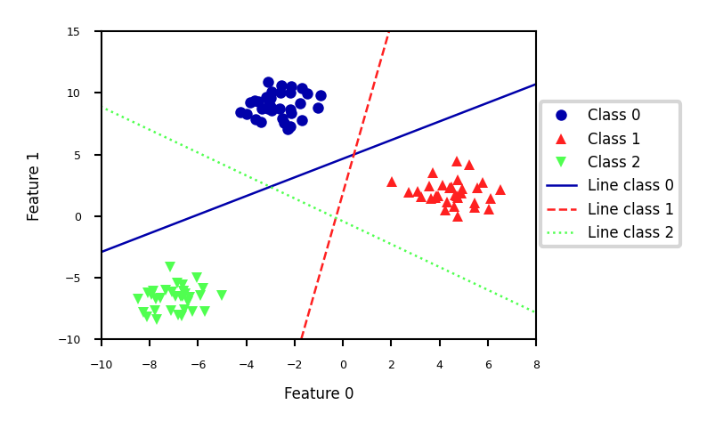

- Every binary classifiers makes a prediction, the one with the highest score (>0) wins

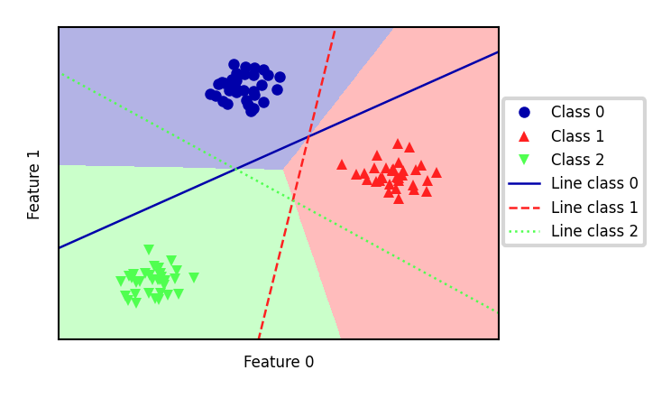

### one-vs-one

- An alternative is to learn a binary model for every *combination* of two classes
  - For $C$ classes, this results in $\frac{C(C-1)}{2}$ binary models
  - Each point is classified according to a majority vote amongst all models
  - Can also be a 'soft vote': sum up the probabilities (or decision values) for all models. The class with the highest sum wins.
- Requires more models than one-vs-rest, but training each one is faster
  - Only the examples of 2 classes are included in the training data
- Recommended for algorithms than learn well on small datasets
  - Especially SVMs and Gaussian Processes

## Linear models overview

| Name | Representation | Loss function | Optimization | Regularization |
| --- | --- | --- | --- | --- |
| Least squares | Linear function (R) | SSE | CFS or SGD | None |
| Ridge | Linear function (R) | SSE + L2 | CFS or SGD | L2 strength ($\alpha$) |
| Lasso | Linear function (R) | SSE + L1 | Coordinate descent | L1 strength ($\alpha$) |
| Elastic-Net | Linear function (R) | SSE + L1 + L2 | Coordinate descent | $\alpha$, L1 ratio ($\rho$) |
| SGDRegressor | Linear function (R) | SSE, Huber, $\epsilon$-ins,... + L1/L2 | SGD | L1/L2, $\alpha$ |
| Logistic regression | Linear function (C) | Log + L1/L2 | SGD, coordinate descent,... | L1/L2, $\alpha$ |
| Ridge classification | Linear function (C) | SSE + L2 | CFS or SGD | L2 strength ($\alpha$) |
| Linear SVM | Support Vectors | Hinge(1) | Quadratic programming or SGD | Cost (C) |
| Kernelized SVM | Support Vectors | Hinge(1) | Quadratic programming or SGD | Cost (C), $\gamma$,... |
| Least Squares SVM | Support Vectors | Squared Hinge | Linear equations or SGD | Cost (C) |
| Perceptron | Linear function (C) | Hinge(0) | SGD | None |
| SGDClassifier | Linear function (C) | Log, (Sq.) Hinge, Mod. Huber,... | SGD | L1/L2, $\alpha$ |

- SSE: Sum of Squared Errors
- CFS: Closed-form solution
- SGD: (Stochastic) Gradient Descent and variants
- (R)egression, (C)lassification

## Summary

- Linear models
  - Good for very large datasets (scalable)
  - Good for very high-dimensional data (not for low-dimensional data)
- Can be used to fit non-linear or low-dim patterns as well (see later)
  - Preprocessing: e.g. Polynomial or Poisson transformations
  - Generalized linear models (kernelization)
- Regularization is important. Tune the regularization strength ($\alpha$)
  - Ridge (L2): Good fit, sometimes sensitive to outliers
  - Lasso (L1): Sparse models: fewer features, more interpretable, faster
  - Elastic-Net: Trade-off between both, e.g. for correlated features
- Most can be solved by different optimizers (solvers)
  - Closed form solutions or quadratic/linear solvers for smaller datasets
  - Gradient descent variants (SGD,CD,SAG,CG,...) for larger ones
- Multi-class classification can be done using a one-vs-all approach